# MLR Analysis

Hector Mathonsi

14 October 2024

# Parametric vs. Non-Parametric Tests

A researcher collected data on R&D expenditure per sales ratio and the price per earnings ratio of small, medium and large sized companies. The `company.csv` dataset consist of the following variables:

- **Size** = company size classification
- **ESratio** = expenditure per sales ratio
- **PEratio** = price per earnings ratio

## Load the Data

```r
company <- read.csv("../data/company.csv", header = TRUE)
company
```

| Size | ESratio | PEratio |
| --- | --- | --- |
| Small | 0.003 | 3.1 |
| Small | 0.004 | 9.5 |
| Small | 0.009 | 2.9 |
| Small | 0.021 | 0.8 |
| Small | 0.023 | 1.5 |
| Small | 0.030 | 5.5 |
| Small | 0.035 | 4.5 |
| Small | 0.037 | 3.8 |
| Small | 0.044 | 0.5 |
| Small | 0.051 | 6.3 |

[output cut: 20 more lines]

## Correlation Analysis

Calculate and compare the Pearson and the Spearman correlation coefficients between ESratio and PEratio. State whether the two coefficients are similar or different, and what this result implies about this data.

```r
cor(company$ESratio, company$PEratio, method = "pearson")
```

```
[1] 0.6285545
```

```r
cor(company$ESratio, company$PEratio, method = "spearman")
```

```
[1] 0.6113652
```

**Interpretation:** The two correlation coefficients are similar. This implies that the relationship between the two variables is linear and also it is unlikely that there are extreme outliers in the data.

## Boxplot

Create a box-and-whisker plot of PEratio by company size. Briefly comment on the graph.

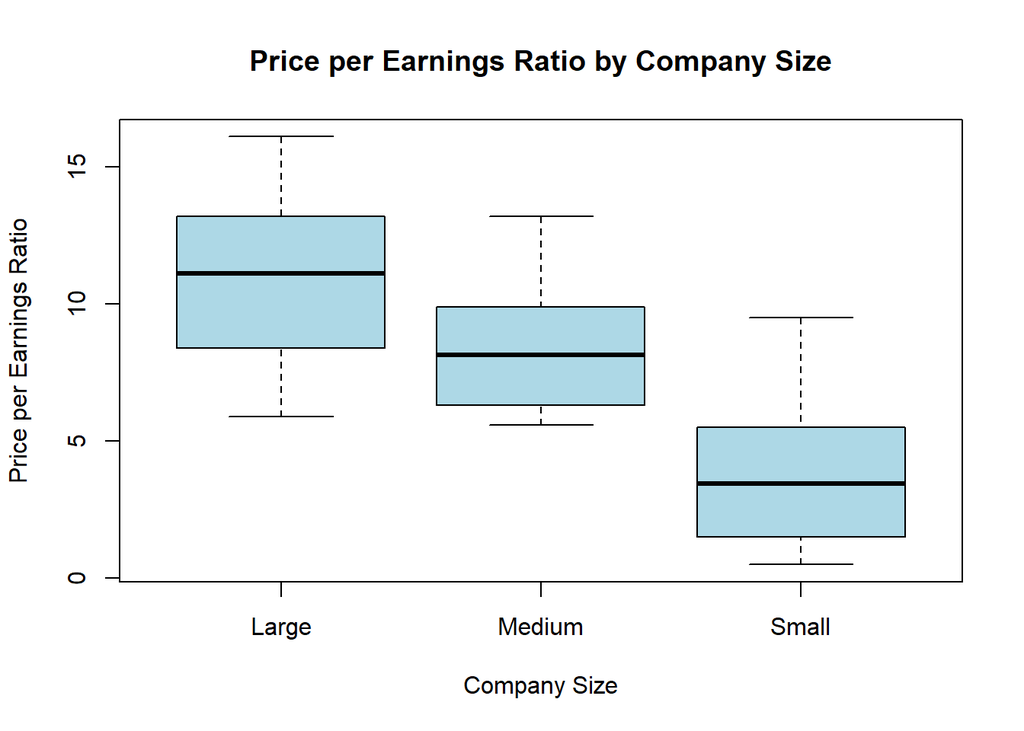

```r
boxplot(company$PEratio ~ company$Size, main = "Price per Earnings Ratio by Company Size", xlab = "Company Size", ylab = "Price per Earnings Ratio", col = "lightblue")
```

**Comment:** The distributions of PERatio appear different for companies of different sizes.

## Kruskal-Wallis Test

The researcher wants to compare the PEratio by company size using non-parametric methods. Explain why this is a good approach for this data. Use the appropriate method to test the following hypothesis at the 5% level of significance: H0: are group medians are equal H1: at least one group has a different median

```r
kruskal.test(PEratio ~ Size, data = company)
```

```
    Kruskal-Wallis rank sum test

data:  PEratio by Size
Kruskal-Wallis chi-squared = 16.271, df = 2, p-value = 0.000293
```

**Conclusion:** Since the p-value is less than 0.05, we reject the null hypothesis and conclude that, at 5% of level of significance, there is sufficient evidence that at least one group has different median compared to the others.

# MLR: Boiler Analysis

In a production facility, an accurate estimate of the man-hours needed to complete a task is important to accurately plan, time and quote a project. A manufacturer of boiler drums wants to predict the number of man-hours needed to assemble and install a boiler drum at a client’s job site. To assess this, data for 34 boilers were collected. The boiler.csv data file consists of the following variables:

- **Hours** = man-hours needed to install the boiler drum
- **Capacity** = boiler capacity, in thousands of pounds per hour
- **Pressure** = boiler design pressure, in pounds per square inch
- **Type** = drum type, where 1 = steam, and 0 = mud

## Load the Data

```r
boiler <- read.csv("../data/boiler.csv", header = TRUE)
boiler
```

| Hours | Capacity | Pressure | Type |
| --- | --- | --- | --- |
| 3137 | 120 | 375 | 1 |
| 3590 | 65 | 750 | 1 |
| 4526 | 150 | 500 | 1 |
| 4023 | 150 | 325 | 1 |
| 7606 | 610 | 1500 | 1 |
| 3748 | 88 | 399 | 1 |
| 2972 | 88 | 399 | 1 |
| 3163 | 88 | 399 | 1 |
| 4065 | 90 | 1140 | 1 |
| 2048 | 30 | 325 | 1 |

[output cut: 24 more lines]

## Fit the MLR Model

Fit a multiple linear regression model to predict Hours using Capacity and Pressure. Provide and interpret the model fit and coefficients of the regression model at the 5% level of significance.

```r
hour_model <- lm(Hours ~ Capacity + Pressure, data = boiler)
summary(hour_model)
```

```
Call:
lm(formula = Hours ~ Capacity + Pressure, data = boiler)

Residuals:
     Min       1Q   Median       3Q      Max
-2274.84  -964.78   -11.76   983.35  2120.16

Coefficients:
             Estimate Std. Error t value Pr(>|t|)
(Intercept) 2408.1822   410.2622   5.870 1.78e-06 ***
Capacity       5.6446     1.2685   4.450 0.000103 ***
Pressure      -0.2437     0.6171  -0.395 0.695620
---
Signif. codes:  0 '***' 0.001 '**' 0.01 '*' 0.05 '.' 0.1 ' ' 1

Residual standard error: 1269 on 31 degrees of freedom
Multiple R-squared:   0.47, Adjusted R-squared:  0.4358
F-statistic: 13.75 on 2 and 31 DF,  p-value: 5.323e-05
```

## Residual Analysis

If a Cook’s distance measure for an observation is greater than 0.5, the data point is quite likely to be an outlier. Check for outliers in the model using the Cook’s distance measure.

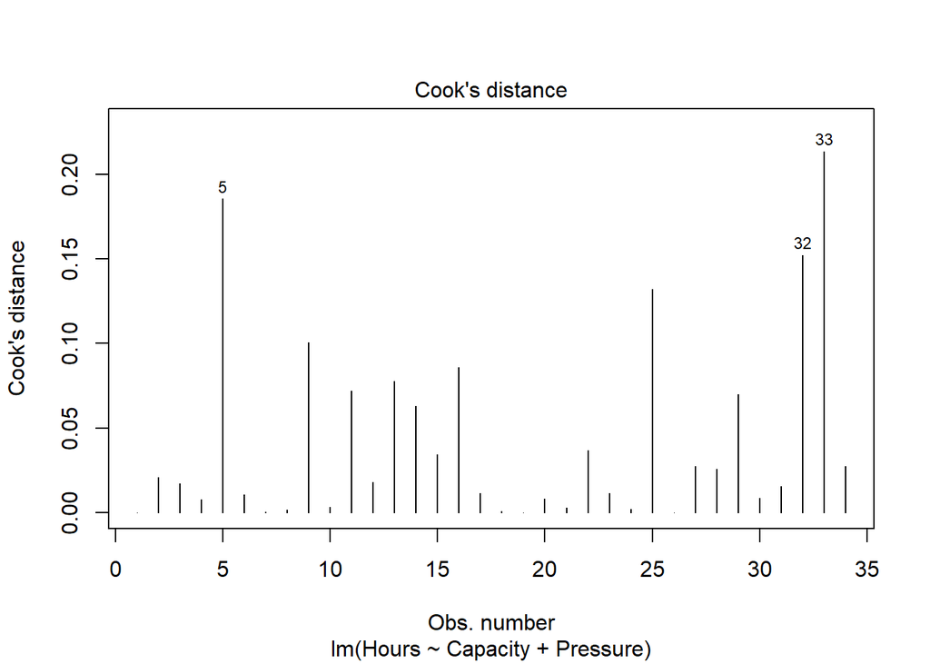

```r
plot(hour_model, which = 4)   # Residuals vs Leverage: Check for influential points
```

**Conclusion:** All the Cook’s distance values are less than 0.5. Therefore, there are no obvious outliers in the data.

## Two Simple Linear Regression Models

Compare the relationship between Capacity and Hours for the two different drum types. Fit a multiple linear regression model to compare the two simple linear regression lines of the two drum types at the 5% level of significance. Then, use the 5% level of significance to determine if the intercepts and slopes of the two regression lines are equal or not.

```r
boiler$Capacity_type <- boiler$Capacity*boiler$Type
hour_lm <- lm(Hours ~ Type + Capacity + Capacity_type, data = boiler)
summary(hour_lm)
```

```
Call:
lm(formula = Hours ~ Type + Capacity + Capacity_type, data = boiler)

Residuals:
    Min      1Q  Median      3Q     Max
-973.08 -390.96   77.98  433.53  856.69

Coefficients:
               Estimate Std. Error t value Pr(>|t|)
(Intercept)   1759.4391   244.0099   7.211 5.03e-08 ***
Type           967.7093   330.8182   2.925 0.006500 **
Capacity         3.6051     0.6844   5.268 1.09e-05 ***
Capacity_type    3.8023     0.9522   3.993 0.000389 ***
---
Signif. codes:  0 '***' 0.001 '**' 0.01 '*' 0.05 '.' 0.1 ' ' 1

Residual standard error: 589.6 on 30 degrees of freedom
Multiple R-squared:  0.8893,    Adjusted R-squared:  0.8782
F-statistic:  80.3 on 3 and 30 DF,  p-value: 1.957e-14
```